# Linear Mixed Models Workshop

Andrew Stewart

```r
library(tidyverse)
library(Hmisc)
library(lme4)
library(lmerTest)
library(emmeans)
library(visdat)
```

## Linear Mixed Models

Today we are now going to turn to mixed models.

# Q1

Within R, import the dataset “data1.csv”. These data are from a reaction time experiment. Fifty participants had to respond to a word on the screen. Their task was to press a button on a button box only when they recognized the word (our DV is measures in milliseconds). The words were either Rare or Common. The design is repeated measures. We might expect Common words to be recognized more quickly than Common words. Run the appropriate LMM to determine whether this is indeed correct.

```r
data <- read_csv("data1.csv")
```

First we need to make sure that our Subject, Item, and Condition columns are all factors - the first two we will use as our random effects, the third as our fixed effect:

```r
data$Subject <- as.factor(data$Subject)
data$Item <- as.factor(data$Item)
data$Condition <- as.factor(data$Condition)
```

Let’s build a plot:

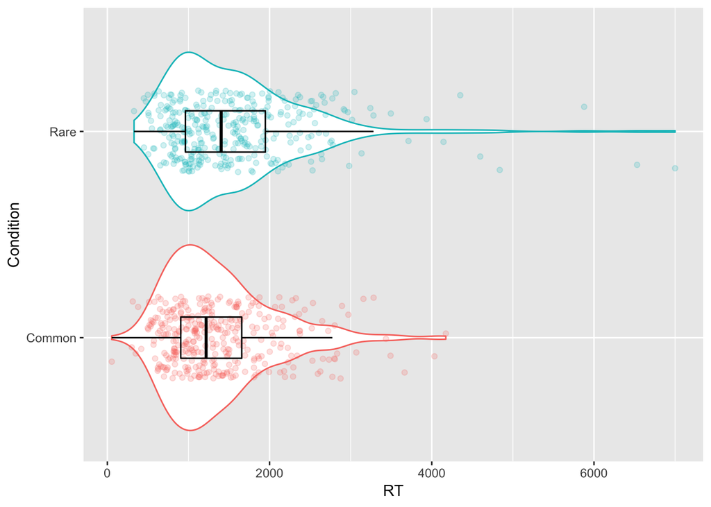

```r
data %>%
  ggplot(aes(x = Condition, y = RT, colour = Condition)) +
  geom_violin() +
  geom_jitter(alpha = .2, width = .2) +
  guides(colour = FALSE) +
  geom_boxplot(width = .2, colour = "black", alpha = 0) +
  coord_flip()
```

Generate some descriptives:

```r
data %>% group_by(Condition) %>%
  filter(!is.na(RT)) %>%
  summarise(mean = mean(RT), sd = sd(RT))
```

```
## # A tibble: 2 x 3
##   Condition  mean    sd
##   <fct>     <dbl> <dbl>
## 1 Common    1370.  658.
## 2 Rare      1563.  864.
```

Let’s run a basic mixed model first:

```r
model1 <- lmer(RT ~ Condition + (1 + Condition | Subject) + (1 + Condition | Item), data = data, REML = TRUE )
summary(model1)
```

```
## Linear mixed model fit by REML. t-tests use Satterthwaite's method [
## lmerModLmerTest]
## Formula: RT ~ Condition + (1 + Condition | Subject) + (1 + Condition |
##     Item)
##    Data: data
##
## REML criterion at convergence: 11077.1
##
## Scaled residuals:
##     Min      1Q  Median      3Q     Max
## -2.0656 -0.5453 -0.1536  0.3563  7.0026
##
## Random effects:
##  Groups   Name          Variance Std.Dev. Corr
##  Subject  (Intercept)    74393   272.8
##           ConditionRare  16582   128.8    -0.01
##  Item     (Intercept)   110721   332.7
##           ConditionRare 125847   354.7    -0.21
##  Residual               364848   604.0
## Number of obs: 699, groups:  Subject, 50; Item, 28
##
## Fixed effects:
##               Estimate Std. Error      df t value Pr(>|t|)
## (Intercept)    1367.51      80.54   38.01  16.980   <2e-16 ***
## ConditionRare   200.10      83.17   25.80   2.406   0.0236 *
## ---
## Signif. codes:  0 '***' 0.001 '**' 0.01 '*' 0.05 '.' 0.1 ' ' 1
##
## Correlation of Fixed Effects:
##             (Intr)
## ConditionRr -0.290
```

We can see we have an effect of condition - the Intercept corresponds to our ‘Common’ condition and our ConditionRare estimate corresponds to the difference between our ‘Common’ and ‘Rare’ conditions. In other words, our ‘Rare’ condition words are about 200 msec. slower to respond to. That fits with the descriptives we calculated earlier. The estimates differ slighly from our descriptives as we have a missing data point which we can see by using the filter() function to display cases where we have missing RT data (indicated by NA).

```r
filter(data, is.na(RT))
```

```
## # A tibble: 1 x 4
##   Subject Item     RT Condition
##   <fct>   <fct> <dbl> <fct>
## 1 21      11       NA Rare
```

How do the residuals look?

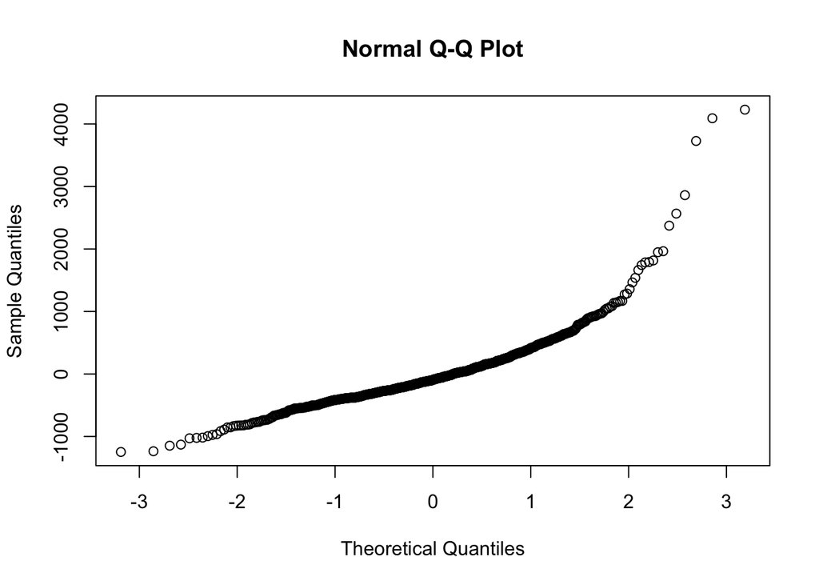

```r
qqnorm(residuals(model1))
```

OK, so these don’t look too normal. We now have a couple of options - we could log transform our DV…

```r
model2 <- lmer(log(RT) ~ Condition + (1 | Subject) + (1 | Item), data = data, REML = TRUE)
summary(model2)
```

```
## Linear mixed model fit by REML. t-tests use Satterthwaite's method [
## lmerModLmerTest]
## Formula: log(RT) ~ Condition + (1 | Subject) + (1 | Item)
##    Data: data
##
## REML criterion at convergence: 784.6
##
## Scaled residuals:
##     Min      1Q  Median      3Q     Max
## -5.9413 -0.5733 -0.0480  0.5705  4.1626
##
## Random effects:
##  Groups   Name        Variance Std.Dev.
##  Subject  (Intercept) 0.04154  0.2038
##  Item     (Intercept) 0.05735  0.2395
##  Residual             0.14471  0.3804
## Number of obs: 699, groups:  Subject, 50; Item, 28
##
## Fixed effects:
##                Estimate Std. Error        df t value Pr(>|t|)
## (Intercept)     7.10812    0.05738  51.13837 123.872  < 2e-16 ***
## ConditionRare   0.12601    0.02880 622.10289   4.376 1.42e-05 ***
## ---
## Signif. codes:  0 '***' 0.001 '**' 0.01 '*' 0.05 '.' 0.1 ' ' 1
##
## Correlation of Fixed Effects:
##             (Intr)
## ConditionRr -0.251
```

The same finding holds - with the ‘Rare’ condition taking longer to read. Interpreting the estimates is harder though as they are log transformed… Do the residuals now look normally distributed?

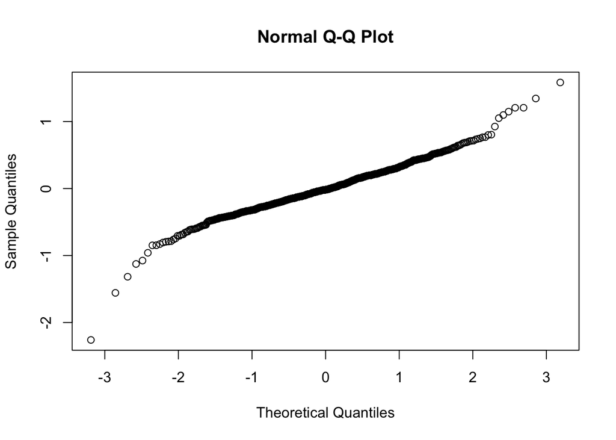

```r
qqnorm(residuals(model2))
```

This is looking better than modelling over the untransformed data. Another option would be to build a generalised linear mixed model assuming sampling from the Gamma distribution.

# Q2

Within R, import the dataset “data2.csv”. These data are from an experiment where we measured how long people spent looking at images that appeared on screen. The images depicted either positive, neutral, or negative scenes. This is our one factor with three levels. The design was repeated measures. Perform the appropriate LMM analysis and determine whether people spent a different amount of time looking at the positive relative to the negative images, and the neutral relative to the negative images.

First we need to set our appropriate factors.

```r
data$Subject <- as.factor(data$Subject)
data$Item <- as.factor(data$Item)
data$Image <- as.factor(data$Image)
```

Let’s visual our data:

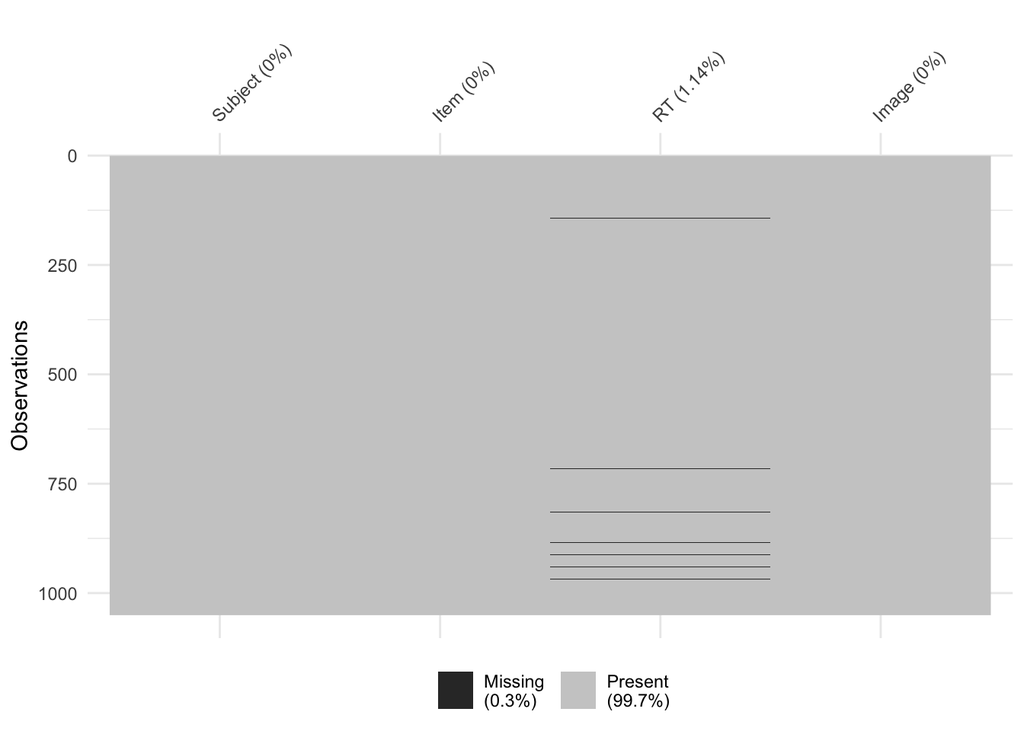

```r
vis_miss(data)
```

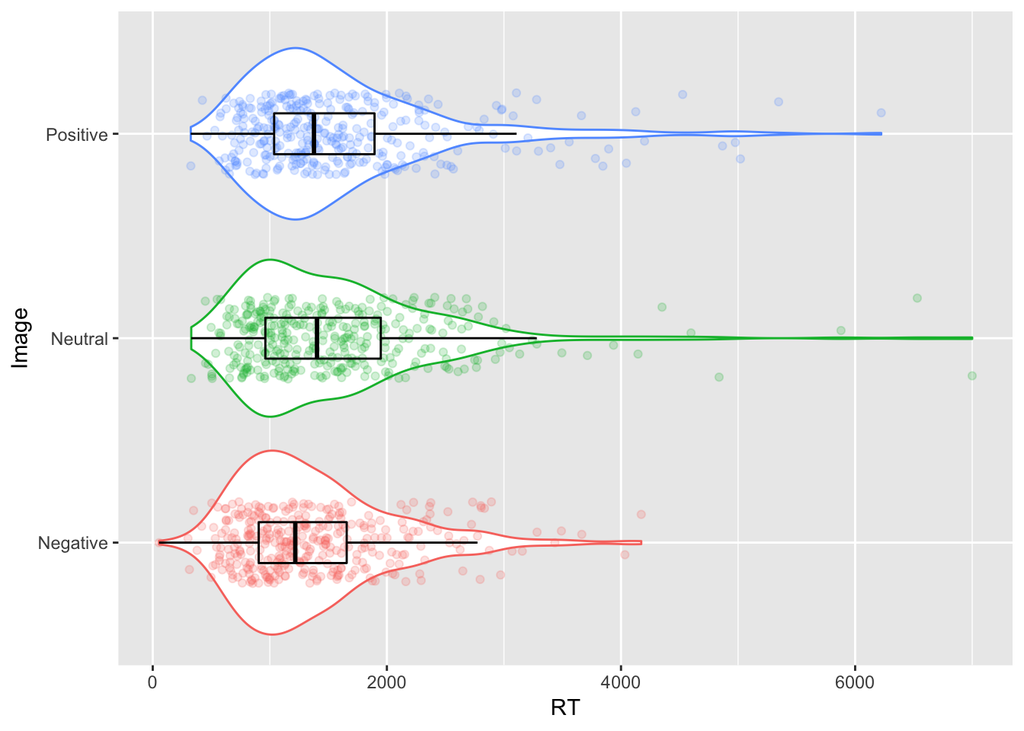

```r
data %>%
  ggplot(aes (x = Image, y = RT, colour = Image)) +
  geom_violin() +
  geom_jitter(alpha = .2, width = .2) +
  guides(colour = FALSE) +
  geom_boxplot(width = .2, colour = "black", alpha = 0) +
  coord_flip()
```

We have some missing data so need to use na.rm = TRUE to ignore those points.

```r
data %>%
  group_by(Image) %>%
  summarise(mean = mean(RT, na.rm = TRUE), sd = sd(RT, na.rm = TRUE))
```

```
## # A tibble: 3 x 3
##   Image     mean    sd
##   <fct>    <dbl> <dbl>
## 1 Negative 1370.  658.
## 2 Neutral  1563.  864.
## 3 Positive 1591.  855.
```

Let’s build our model.

```r
model <- lmer(RT ~ Image + (1 | Subject) + (1 | Item), data = data, REML = TRUE)
summary(model)
```

```
## Linear mixed model fit by REML. t-tests use Satterthwaite's method [
## lmerModLmerTest]
## Formula: RT ~ Image + (1 | Subject) + (1 | Item)
##    Data: data
##
## REML criterion at convergence: 16539.5
##
## Scaled residuals:
##     Min      1Q  Median      3Q     Max
## -2.4166 -0.5898 -0.1799  0.3669  7.1973
##
## Random effects:
##  Groups   Name        Variance Std.Dev.
##  Subject  (Intercept)  86182   293.6
##  Item     (Intercept) 124010   352.2
##  Residual             435698   660.1
## Number of obs: 1038, groups:  Subject, 50; Item, 28
##
## Fixed effects:
##               Estimate Std. Error      df t value Pr(>|t|)
## (Intercept)    1366.88      86.01   56.29  15.892  < 2e-16 ***
## ImageNeutral    198.82      49.96  958.73   3.980 7.42e-05 ***
## ImagePositive   208.55      50.46  960.31   4.133 3.89e-05 ***
## ---
## Signif. codes:  0 '***' 0.001 '**' 0.01 '*' 0.05 '.' 0.1 ' ' 1
##
## Correlation of Fixed Effects:
##             (Intr) ImgNtr
## ImageNeutrl -0.290
## ImagePositv -0.287  0.494
```

How do the residuals look?

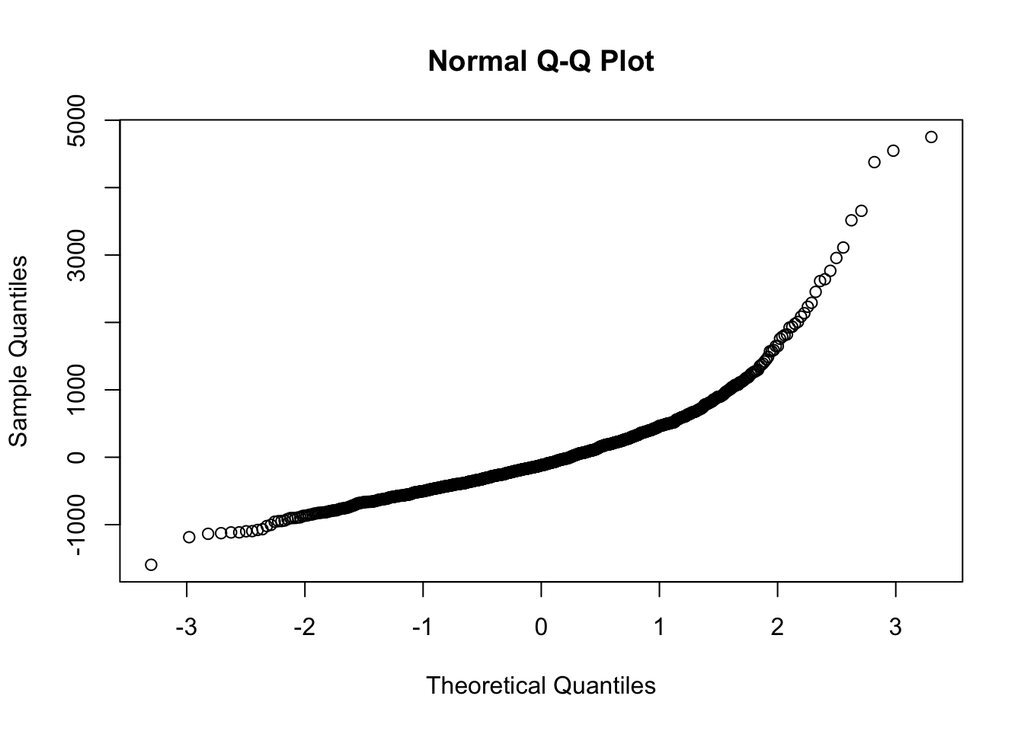

```r
qqnorm(residuals(model))
```

OK, maybe we should log transform the data:

```r
model <- lmer(log(RT) ~ Image + (1 | Subject) + (1 | Item), data = data, REML = TRUE)
summary(model)
```

```
## Linear mixed model fit by REML. t-tests use Satterthwaite's method [
## lmerModLmerTest]
## Formula: log(RT) ~ Image + (1 | Subject) + (1 | Item)
##    Data: data
##
## REML criterion at convergence: 1102.5
##
## Scaled residuals:
##     Min      1Q  Median      3Q     Max
## -6.0952 -0.6299 -0.0514  0.5725  4.5107
##
## Random effects:
##  Groups   Name        Variance Std.Dev.
##  Subject  (Intercept) 0.04016  0.2004
##  Item     (Intercept) 0.05636  0.2374
##  Residual             0.14193  0.3767
## Number of obs: 1038, groups:  Subject, 50; Item, 28
##
## Fixed effects:
##                Estimate Std. Error        df t value Pr(>|t|)
## (Intercept)     7.10859    0.05676  54.61393 125.236  < 2e-16 ***
## ImageNeutral    0.12502    0.02852 958.97751   4.384 1.29e-05 ***
## ImagePositive   0.13696    0.02880 960.17168   4.755 2.28e-06 ***
## ---
## Signif. codes:  0 '***' 0.001 '**' 0.01 '*' 0.05 '.' 0.1 ' ' 1
##
## Correlation of Fixed Effects:
##             (Intr) ImgNtr
## ImageNeutrl -0.251
## ImagePositv -0.248  0.494
```

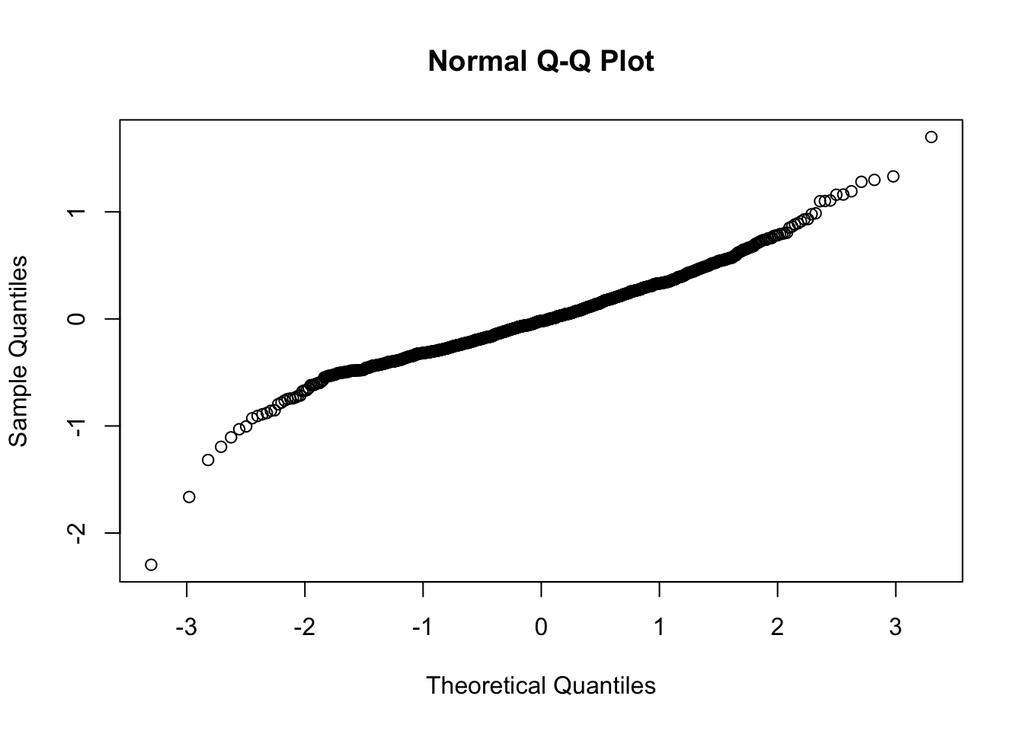

```r
qqnorm(residuals(model))
```

OK, with log transformed data our residuals look a lot better. We find that the Neutral and Positive conditions differ from the Negative.

# Q3

Now we’re going to import the dataset “data3.csv”. These data are from a repeated measures experiment where participants had to respond to a target word (measured by our DV which is labelled “Time”). The target word always followed a prime word. Prime and Target are our two factors – each with two levels – Positive vs. Negative. We are interested in whether there is a priming effect (i.e., Positive target words responded to more quickly after Positive than after Negative Primes, and Negative target words responded to more quickly after Negative than after Positive Primes). We need to build the appropriate LMM to determine whether this is indeed correct.

```r
data <- read_csv("data3.csv")
```

First we need to create our factors:

```r
data$Subject <- as.factor(data$Subject)
data$Item <- as.factor(data$Item)
data$Prime <- as.factor(data$Prime)
data$Target <- as.factor(data$Target)
```

As it is a factorial experiment, we need to set up our contrast weightings for our two factors. This allows for easier intepretation of the paramester estimates - the intercept will correspond to the Grand Mean (i.e., the mean of our conditions).

```r
contrasts(data$Prime) <- matrix(c(.5, -.5))
contrasts(data$Target) <- matrix(c(.5, -.5))
```

We can now check the structure of our data:

```r
head(data)
```

```
## # A tibble: 6 x 5
##   Subject Item   Time Prime    Target
##   <fct>   <fct> <dbl> <fct>    <fct>
## 1 1       3       407 Negative Negative
## 2 1       7       367 Negative Negative
## 3 1       11      352 Negative Negative
## 4 1       15      293 Negative Negative
## 5 1       19      227 Negative Negative
## 6 1       23      497 Negative Negative
```

Let’s visualise our data:

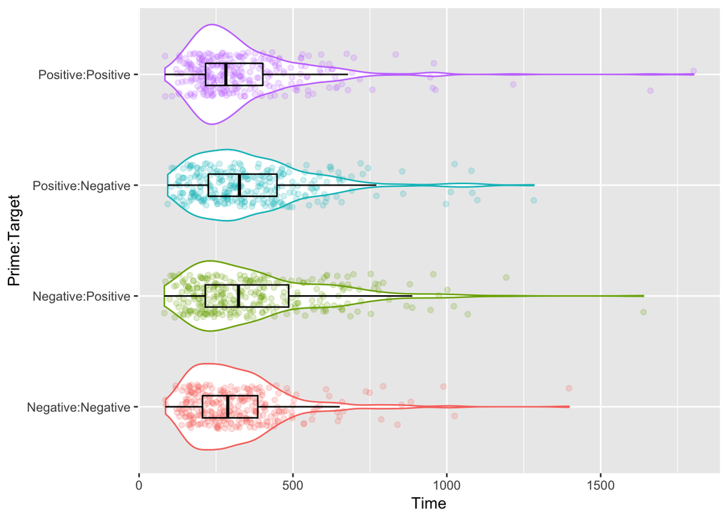

```r
data %>%
  ggplot(aes(x = Prime:Target, y = Time, colour = Prime:Target)) +
  geom_violin() +
  geom_jitter(alpha = .2, width = .2) +
  guides(colour = FALSE) +
  geom_boxplot(width = .2, colour = "black", alpha = 0) +
  coord_flip()
```

Now we are going to generate some descriptives, filtering out cases where we have missing data in our dependent variable (labelled “Time”).

```r
data %>%
  filter(!is.na(Time)) %>%
  group_by(Prime, Target) %>%
  summarise(mean = mean(Time), sd = sd(Time))
```

```
## # A tibble: 4 x 4
## # Groups:   Prime [2]
##   Prime    Target    mean    sd
##   <fct>    <fct>    <dbl> <dbl>
## 1 Negative Negative  321.  167.
## 2 Negative Positive  376.  219.
## 3 Positive Negative  361.  191.
## 4 Positive Positive  337.  203.
```

```r
data %>% filter(is.na(Time))
```

```
## # A tibble: 121 x 5
##    Subject Item   Time Prime    Target
##    <fct>   <fct> <dbl> <fct>    <fct>
##  1 1       29       NA Positive Positive
##  2 4       27       NA Negative Negative
##  3 4       24       NA Negative Positive
##  4 5       24       NA Negative Positive
##  5 5       30       NA Positive Negative
##  6 6       19       NA Negative Negative
##  7 6       12       NA Negative Positive
##  8 6       14       NA Positive Negative
##  9 7       3        NA Negative Negative
## 10 7       11       NA Negative Negative
## # … with 111 more rows
```

Note we have a little missing data (121 rows) - not a big deal, but something that you could report.

We could calculate and plot the amount of missing data per participant:

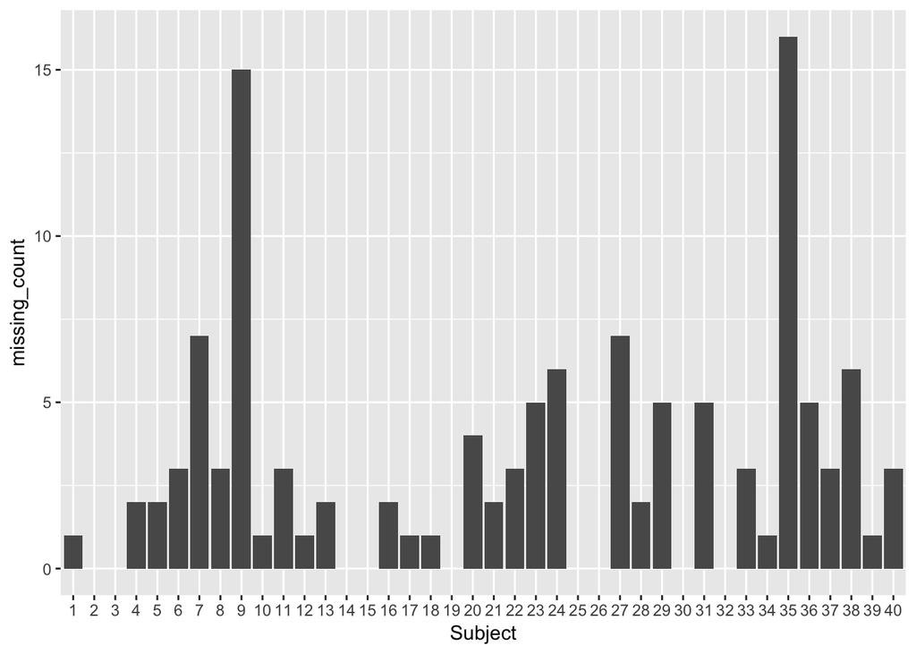

```r
data %>%
  group_by(Subject) %>%
  summarise(missing_count = sum(is.na(Time))) %>%
  ggplot(aes(x = Subject, y = missing_count)) +
  geom_col()
```

```r
model <- lmer(Time ~ Prime * Target + (1 + Prime * Target | Subject) + (1 + Prime * Target | Item), data = data, REML = TRUE)
```

```
## singular fit
```

```r
summary(model)
```

```
## Linear mixed model fit by REML. t-tests use Satterthwaite's method [
## lmerModLmerTest]
## Formula: Time ~ Prime * Target + (1 + Prime * Target | Subject) + (1 +
##     Prime * Target | Item)
##    Data: data
##
## REML criterion at convergence: 15336.5
##
## Scaled residuals:
##     Min      1Q  Median      3Q     Max
## -3.0618 -0.6053 -0.1849  0.4015  6.4724
##
## Random effects:
##  Groups   Name           Variance Std.Dev. Corr
##  Subject  (Intercept)     6088.4   78.03
##           Prime1           801.7   28.32    0.23
##           Target1         2158.4   46.46   -0.55 -0.94
##           Prime1:Target1   294.1   17.15   -0.57  0.66 -0.37
##  Item     (Intercept)     1438.9   37.93
##           Prime1           146.8   12.12   -1.00
##           Target1          137.2   11.71   -1.00  1.00
##           Prime1:Target1   342.1   18.50   -1.00  1.00  1.00
##  Residual                30111.8  173.53
## Number of obs: 1159, groups:  Subject, 40; Item, 32
##
## Fixed effects:
##                 Estimate Std. Error        df t value Pr(>|t|)
## (Intercept)    344.37768   14.95496  51.24156  23.028  < 2e-16 ***
## Prime1          -0.03613   11.36706  68.03416  -0.003  0.99747
## Target1        -15.26519   12.77002  47.74892  -1.195  0.23784
## Prime1:Target1 -77.24959   20.88072 229.10990  -3.700  0.00027 ***
## ---
## Signif. codes:  0 '***' 0.001 '**' 0.01 '*' 0.05 '.' 0.1 ' ' 1
##
## Correlation of Fixed Effects:
##             (Intr) Prime1 Targt1
## Prime1      -0.006
## Target1     -0.330 -0.179
## Prim1:Trgt1 -0.129  0.068  0.005
## convergence code: 0
## singular fit
```

This suggests our model is over-parameterised - the “singular fit” message tells us we have combinations of our effects where some dimensions of the variance-covariance matrix in our model are effectively zero. In other words, we are trying to estimate more parameters than our data will allow. In practice you might want to simplify your random effects structure until you find a model that isn’t over parameterised. For the time being, let’s stick with this model.

Our interaction is significant - we now need to run pairwise comparisons to figure out what condition(s) differs from what other condition(s). We need to use the emmeans() function from the emmeans package - let’s do the correction manually as only a couple of pairwise comparisons make theoretical sense. They are Positive/Positive vs Negative/Positive, and Negative/Negative vs Positive/Negative. These are the only pairs where we’re comparing the same target to the same target under the two different levels of our prime. So, we need to multiply by 2 the calculated p-values for these comparisons to correct for familywise error.

```r
emmeans(model, pairwise ~ Prime * Target, adjust = "none")
```

```
## $emmeans
##  Prime    Target   emmean   SE   df lower.CL upper.CL
##  Negative Negative    317 15.2 32.1      286      348
##  Positive Negative    356 17.3 38.1      321      391
##  Negative Positive    371 20.4 41.4      330      412
##  Positive Positive    333 18.7 40.6      295      371
##
## Degrees-of-freedom method: kenward-roger
## Confidence level used: 0.95
##
## $contrasts
##  contrast                              estimate   SE   df t.ratio p.value
##  Negative,Negative - Positive,Negative    -38.7 16.0 20.1 -2.416  0.0253
##  Negative,Negative - Negative,Positive    -53.9 16.6 21.6 -3.249  0.0038
##  Negative,Negative - Positive,Positive    -15.3 15.6 19.0 -0.983  0.3381
##  Positive,Negative - Negative,Positive    -15.2 18.6 25.9 -0.820  0.4199
##  Positive,Negative - Positive,Positive     23.4 16.5 21.6  1.416  0.1710
##  Negative,Positive - Positive,Positive     38.6 15.0 17.6  2.581  0.0190
```

What do the residuals look like?

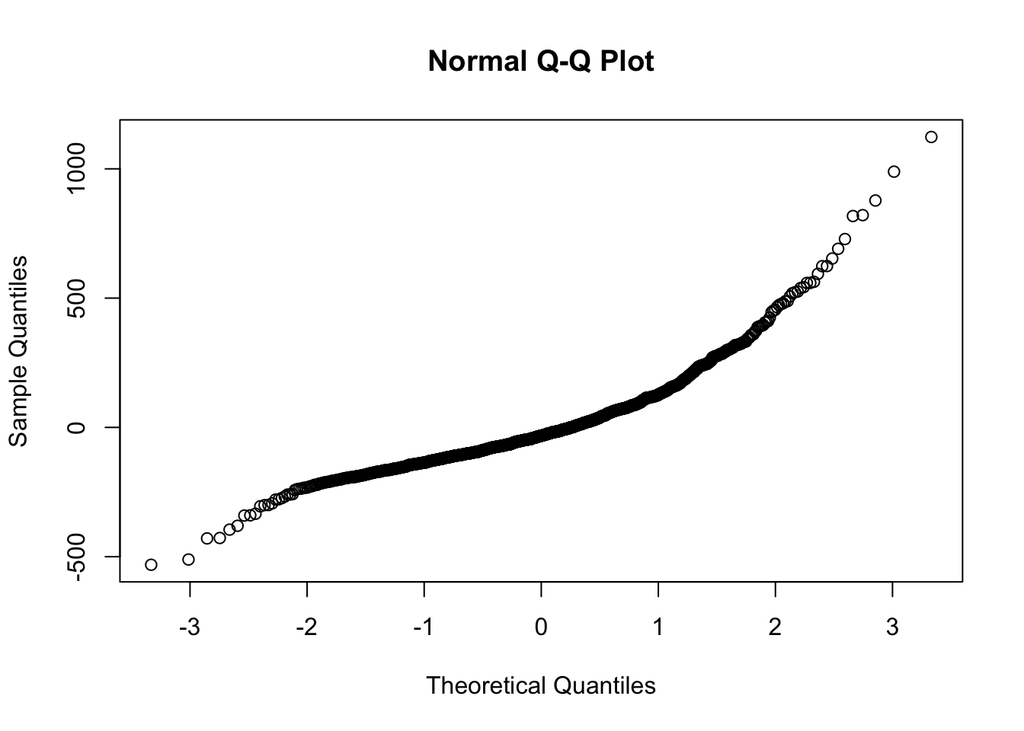

```r
qqnorm(residuals(model))
```

The above residuals don’t look brilliant. What about log transform? The most complex random effects model we can build is this one (although it looks over-parameterised):

```r
model <- lmer(log(Time) ~ Prime * Target + (1 + Prime * Target | Subject) + (1 + Prime * Target | Item), data = data, REML = TRUE)
summary(model)
```

```
## Linear mixed model fit by REML. t-tests use Satterthwaite's method [
## lmerModLmerTest]
## Formula: log(Time) ~ Prime * Target + (1 + Prime * Target | Subject) +
##     (1 + Prime * Target | Item)
##    Data: data
##
## REML criterion at convergence: 1509.6
##
## Scaled residuals:
##     Min      1Q  Median      3Q     Max
## -2.8691 -0.6772 -0.0315  0.6279  3.1849
##
## Random effects:
##  Groups   Name           Variance  Std.Dev. Corr
##  Subject  (Intercept)    0.0472806 0.21744
##           Prime1         0.0061318 0.07831   0.64
##           Target1        0.0054766 0.07400  -0.17 -0.87
##           Prime1:Target1 0.0078260 0.08846  -1.00 -0.69  0.24
##  Item     (Intercept)    0.0090350 0.09505
##           Prime1         0.0015176 0.03896  -0.94
##           Target1        0.0004747 0.02179  -0.96  0.80
##           Prime1:Target1 0.0001904 0.01380   0.17  0.18 -0.44
##  Residual                0.1901891 0.43611
## Number of obs: 1159, groups:  Subject, 40; Item, 32
##
## Fixed effects:
##                  Estimate Std. Error         df t value Pr(>|t|)
## (Intercept)      5.711416   0.040394  49.602647 141.393  < 2e-16 ***
## Prime1          -0.009572   0.029341  40.169011  -0.326 0.745950
## Target1         -0.026730   0.028525  53.553328  -0.937 0.352931
## Prime1:Target1  -0.181375   0.053279 172.717533  -3.404 0.000825 ***
## ---
## Signif. codes:  0 '***' 0.001 '**' 0.01 '*' 0.05 '.' 0.1 ' ' 1
##
## Correlation of Fixed Effects:
##             (Intr) Prime1 Targt1
## Prime1       0.140
## Target1     -0.111 -0.120
## Prim1:Trgt1 -0.217 -0.070  0.033
## convergence code: 0
## Model failed to converge with max|grad| = 0.016171 (tol = 0.002, component 1)
```

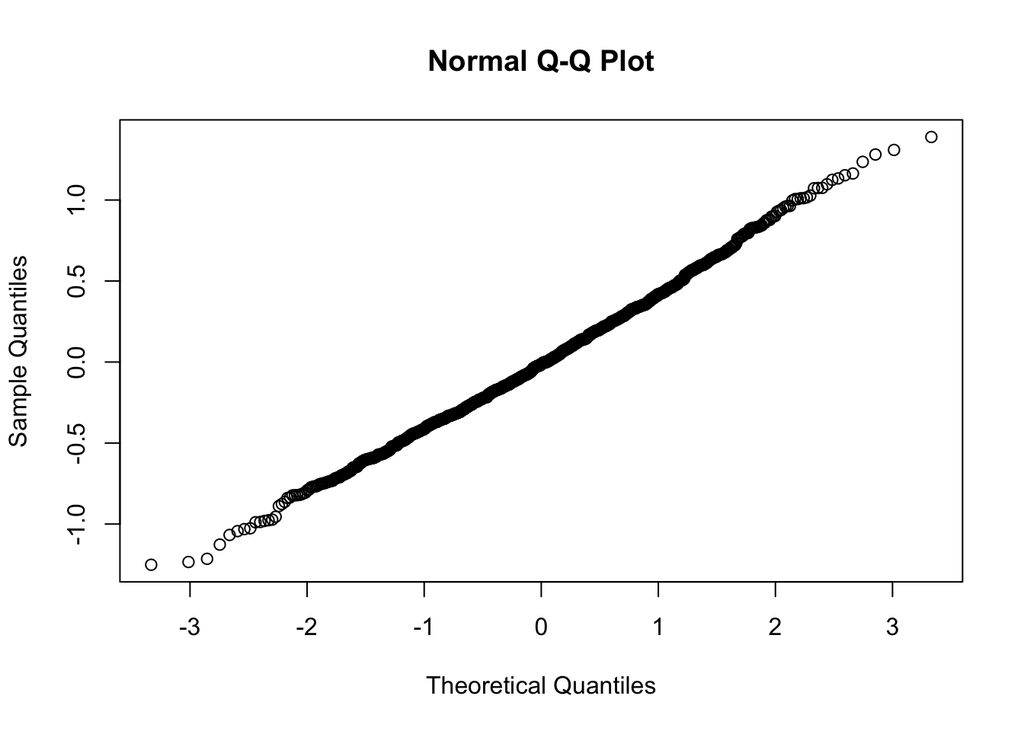

```r
qqnorm(residuals(model))
```

To aid interpretation of our results, we want our comparisons to be reported on the response scale rather thanon the log scale - so we need to specify this when we call the emmeans() function by setting the parameter type to equal “response”.

```r
emmeans(model, pairwise ~ Prime * Target, adjust = "none", type = "response")
```

```
## $emmeans
##  Prime    Target   response   SE   df lower.CL upper.CL
##  Negative Negative      284 12.6 36.2      259      310
##  Positive Negative      314 14.6 39.8      285      345
##  Negative Positive      319 17.0 40.3      286      355
##  Positive Positive      294 12.9 38.9      269      321
##
## Degrees-of-freedom method: kenward-roger
## Confidence level used: 0.95
## Intervals are back-transformed from the log scale
##
## $contrasts
##  contrast                              ratio     SE   df t.ratio p.value
##  Negative,Negative / Positive,Negative 0.905 0.0347 18.3 -2.613  0.0175
##  Negative,Negative / Negative,Positive 0.889 0.0354 19.8 -2.950  0.0080
##  Negative,Negative / Positive,Positive 0.964 0.0372 18.4 -0.942  0.3585
##  Positive,Negative / Negative,Positive 0.983 0.0427 23.4 -0.395  0.6961
##  Positive,Negative / Positive,Positive 1.066 0.0410 18.8  1.662  0.1132
##  Negative,Positive / Positive,Positive 1.084 0.0446 21.2  1.974  0.0615
##
## Tests are performed on the log scale
```

[figure not shown]

Brysbaert, M. & Stevens, M. (2018). Power Analysis and Effect Size in Mixed Effects Models: A Tutorial. *Journal of Cognition, 1*, 1–20, DOI: https://doi.org/10.5334/joc.10

How many observations did we have per condition?

```r
data %>% group_by(Prime, Target) %>% summarise(count = n())
```

```
## # A tibble: 4 x 3
## # Groups:   Prime [2]
##   Prime    Target   count
##   <fct>    <fct>    <int>
## 1 Negative Negative   320
## 2 Negative Positive   320
## 3 Positive Negative   320
## 4 Positive Positive   320
```

We need to run a much higher powered experiment - we need to increase the number of participants, the number of trials, or both!

What about calculating the Bayes factor in support of the experimental vs. the null hypothesis? Have a look at the slides from this morning about how to do that…